# Rapport försäkringskostnader

Malin

2026-04-20

# Försäkringsanalys

Syftet med denna analys är att undersöka vilka faktorer som påverkar försäkringskostnaderna mest. Datasetet innehåller information om kunder, livsstilsfaktorer och hälsorelaterade variabler, och analysen fokuserar på att identifiera mönster och samband i datan.

Rapporten inleds med en beskrivande analys för att få en överblick över datan, följt av en regressionsanalys för att undersöka vilka variabler som bäst förklarar kostnadsskillnaderna mellan kunder. Målet är att ge ett underlag för framtida prissättning.

## 1. Dataförståelse

Datasetet består av 1100 kunder med 14 variabler som beskriver demografiska egenskaper, livsstilsfaktorer och försäkringskostnader. Medelåldern är 42.5 år och medelkostnaden uppgår till cirka 10 060 kr med en stor spridning, vilket indikerar att kostnaderna inte är normalfördelade.

Två variabler har saknade värden, bmi (28 observationer) och annual_checkups (20 observationer). Variabeln exercise_level har dessutom 22 tomma strängar som behöver konverteras till saknade värden.

Flera variabler lagras som text men är kategoriska till sin natur, exempelvis smoker, sex och region, och behöver konverteras till faktorer innan analysen. Inkonsekvent kapitalisering förekommer också och behöver hanteras.

Majoriteten av kunderna är icke-rökare och könsfördelningen är relativt jämn. Variablerna prior_accidents och prior_claims har medelvärden nära noll, vilket tyder på att skador och skadeanmälningar är ovanliga i kundstocken.

## 2. Datastädning och förberedelser

I datastädningen har inkonsekvent kapitalisering och eventuella blanksteg hanterats. Textvariabler har gjorts om till faktorer för att underlätta användningen i regressionsanalysen. Variablerna exercise_level och plan_type har dessutom gjorts om till ordnade faktorer. annual_checkups har gjorts om från decimaltal till heltal. Variabeln customer_id har tagits bort då den inte kommer användas i analysen.

En ny variabel för BMI-kategorier har skapats baserad på WHOs definitioner för att göra det tydligare hur detta kopplar till hälsa. Ytterligare nya variabler som åldersgrupp och risknivå övervägdes men bedömdes inte tillföra något utöver de befintliga variablerna i analysen.

## 3. Beskrivande analys

Könsfördelningen är jämn och regionsskillnaderna är små. Nedan visas de variabler som har tydligast samband med försäkringskostnaderna.

### Kostnadsfördelning

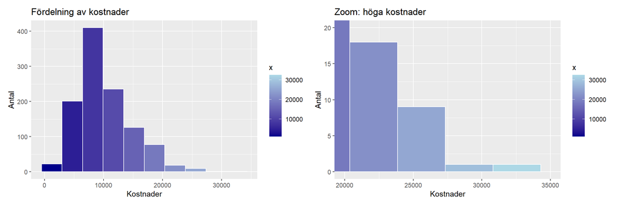

#### Tolkning av kostnadsfördelning

Kostnadsfördelningen är högersnedad med de flesta kunder i intervallet 5 000–15 000 kr. Zoom-grafen visar att ett fåtal kunder har mycket höga kostnader över 25 000 kr, vilket kan påverka modellens precision.

### Kostnader vs rökning och ålder

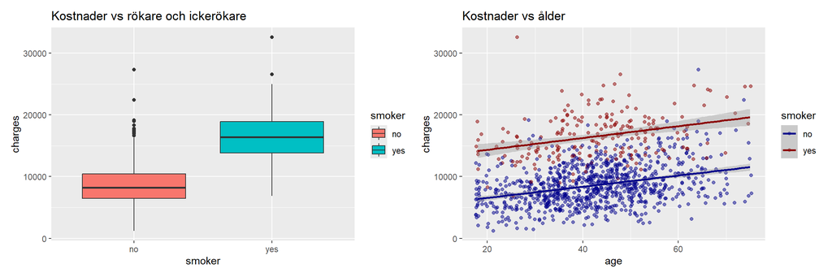

#### Tolkning kostnader vs rökning och ålder

Rökare har tydligt högre kostnader med en median runt 16 000 kr jämfört med cirka 8 000 kr för icke-rökare.

Det finns ett positivt samband mellan ålder och kostnader, där äldre kunder tenderar att ha högre kostnader. Rökare (röda punkter) ligger genomgående högre än icke-rökare oavsett ålder.

Trendlinjerna visar att kostnader ökar med ålder för båda grupperna, men rökare har genomgående högre kostnader oavsett ålder.

## 4. Regressionsanalys

### Modelljämförelse

Modelljämförelse

| modell | r_squared | adjusted_r_squared | residual_se |
| --- | --- | --- | --- |
| Modell 1 | 0.586 | 0.585 | 2945.348 |
| Modell 2 | 0.749 | 0.747 | 2305.575 |

### Faktiska vs predikterade kostnader (modell 2)

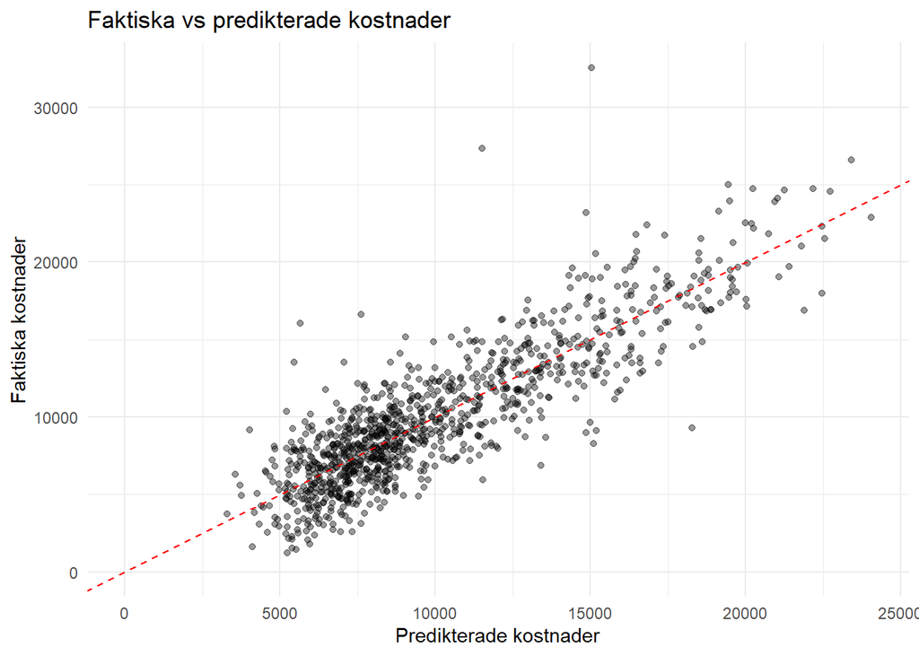

#### Tolkning faktiska vs predikterade kostnader (modell 2)

Punkterna följer den röda linjen relativt väl, vilket indikerar att modellen har god anpassning. Den röda linjen representerar perfekt anpassning, dvs. där faktiska och predikterade kostnader är lika. Vid höga predikterade värden ökar spridningen något, vilket tyder på att modellen är något sämre på att förutsäga kostnader för de dyraste kunderna.

### Sammanfattning av regressionsanalysen

Rökning är den starkaste prediktorn – rökare har i genomsnitt 7 467 kr högre kostnader än icke-rökare. Kronisk sjukdom är den näst starkaste faktorn med 3 780 kr högre kostnader. Högre träningsnivå är associerat med lägre kostnader (-1 020 kr) och högre försäkringsplan med högre kostnader. Ålder, BMI, tidigare olyckor och skadeanmälningar bidrar alla signifikant men med mindre effekter.

Det är värt att notera att koefficienten för tidigare skadeanmälningar sjunker från 1 317 i modell 1 till 902 i modell 2, vilket tyder på att en del av effekten i modell 1 egentligen förklaras av träningsnivå, försäkringsplan och kronisk sjukdom.

**Styrkor:**  
- Modellen förklarar 75% av variationen, vilket är starkt för verkliga data  
- Resultaten följer rimliga mönster – faktorer som rökning och kronisk sjukdom driver kostnader uppåt, vilket stämmer med vad man kan förvänta sig  
- Modellen kan användas som beslutsstöd vid framtida prissättning av liknande kunder

**Svagheter och begränsningar:**  
- 49 observationer togs bort på grund av saknade värden  
- Multikollinearitet mellan prediktorerna har inte undersökts  
- Modellen fångar endast linjära samband  
- Datasetet saknar variabler som rökarhistorik och socioekonomisk status

## 5. Slutsatser

Analysen visar att rökning och kronisk sjukdom är de faktorer som tydligast driver försäkringskostnaderna, följt av ålder, BMI och tidigare olyckor och skadeanmälningar. Regressionsmodellen förklarar 75% av variationen i kostnaderna och bedöms kunna användas som beslutsstöd vid framtida prissättning.

Modellen fångar dock inte icke-linjära samband eller interaktionseffekter mellan variabler. Datasetet saknar också information som rökarhistorik och socioekonomisk status, vilket troligen påverkar kostnaderna i verkligheten.

Möjliga förbättringar inkluderar att undersöka interaktionseffekter, hantera de saknade värdena mer systematiskt samt komplettera datasetet med fler relevanta variabler.

## 6. Självreflektion

Det mest utmanande momentet var att tolka koefficienterna för de ordnade faktorerna och förstå hur förklaringskraften förändrades mellan modellerna där särskilt koefficienten för prior_claims skiljde sig mycket mellan modellerna.

Arbetet uppfyller enligt min bedömning kraven för VG, eftersom det inkluderar modeljämförelse, residualdiagnostik samt kritiskt resonemang kring modellens styrkor, begränsningar och möjliga förbättringar.